# BayesfMRI Demo with Simulated Data

The BayesfMRI package is designed to fit spatial Bayesian models to task fMRI data, with a focus on data that has been projected to the cortical surface. This vignette will use a simulated dataset for illustration. The traditional analysis tool for task fMRI data is the classical general linear model (GLM), a “massive univariate” approach based on fitting a separate location to each location in the brain. While computationally efficient and easy to understand, the classical GLM ignores information shared across neighboring vertices. This results in a loss of estimation efficiency (noisy estimates) and a loss of power to detect true activations. The spatial Bayesian GLM implemented in this package is based on fitting all vertices in each hemisphere in a single model, and assuming a spatial prior distribution on the latent field associated with each task (the unknown image of task activation). The type of priors used are stochastic partial differential equation (SPDE) priors, which are built for data on a triangular mesh, which is the format of cortical surface fMRI data. We refer readers to [@mejia2020bayesian] for further details.

The main functions allow for analyzing several types of datasets:

- Single-subject, single-session analysis through the `BayesGLM` function
- Single-subject, multi-session analysis through the `BayesGLM` function
- Multi-subject analysis through the `summarize_group` function

# Prerequisites

There are several prerequisites to using `BayesfMRI` for spatial Bayesian task fMRI modeling:

1. Installing the R-INLA package
2. Installing Connectome Workbench and the ciftiTools package (not required for this vignette, which only deals with simulated data)
3. Enabling the PARDISO sparse matrix algebra library

**Note: Several chunks in this vignette have `eval=FALSE` to avoid re-installing packages and somewhat long computation times associated with model estimation. To run the vignette from start to finish, set `eval=TRUE` for each chunk, make the appropriate changes as noted in comments, and comment out install lines after successfully installing packages. To use pre-computed results, download and unzip the rds files in the vignettes directory.**

## 1. Installing R-INLA

```r
install.packages("INLA", repos=c(getOption("repos"),
                                 INLA="https://inla.r-inla-download.org/R/stable"), dep=FALSE)
```

## 2. Installing Connectome Workbench and ciftiTools

To work directly with CIFTI files, the `ciftiTools` package should also be installed. **This is not actually required to run this vignette, which uses simulated data.** First, download the [Connectome Workbench](https://www.humanconnectome.org/software/connectome-workbench). Then install `ciftiTools` and use `ciftiTools.setOption` to point to the location of the workbench.

```r
# Replace '/path/to/workbench' with the actual path to the Connectome Workbench folder on your computer.
devtools::install_github("mandymejia/ciftiTools")
library(ciftiTools)
ciftiTools.setOption('wb_path', '/path/to/workbench')
```

## 3. Enabling PARDISO

The PARDISO software was created to optimize the inversions of the sparse, symmetric matrices that arise through the class of priors used by the `INLA` package in R. The use of PARDISO further decreases computation time by allowing for calculations to take place in parallel. To obtain a PARDISO/R-INLA license, run `inla.pardiso()` after installing and loading the `INLA` package. The license should be placed in a file titled “pardiso.lic”, which is pointed to using the `inla.setOption()` function. PARDISO is available for Linux and Mac. While PARDISO is highly recommended, `BayesGLM` can still be run but will take much longer.

```r
# Replace '~/pardiso.lic' with the actual path to the Connectome Workbench folder on your computer.
library(INLA)
inla.pardiso()
inla.setOption(pardiso.license="~/pardiso.lic")
inla.pardiso.check()
```

Now the `BayesfMRI` package can be installed from github.

```r
library(devtools)
install_github('mandymejia/BayesfMRI')
```

```r
# Replace '~/pardiso.lic' with the actual path to the Connectome Workbench folder on your computer.
library(INLA)
if(Sys.info()['sysname'] != "Windows") {
  inla.setOption(pardiso.license="~/pardiso.lic")
}
library(BayesfMRI)
```

# Single-Subject, Single-Session Analysis

## Data Generation

The function `simulate_slice_data()` generates true beta maps and simulated fMRI timeseries data using tools from the `neuRosim` package. The size, location and intensities of the centers of activation can be varied. The data format is a 2-dimensional slice of dimensions $45 \times 54$, and the brain mask is based on an FSL brain template. The response data are created by convolving an activation profile with each true beta map, plus errors, which are simulated as an autoregressive process of order 1 with AR coefficient equal to 0.3 and an error standard deviation of 2. The resulting fMRI timeseries data are then masked and vectorized into a $V \times T$ matrix, where $V$ is the number of voxels in the masked image and $T$ is the length of the time series. For this example, we will simulate a single session of data with 2 tasks.

```r
set.seed(47401)
simulated_data <-
  simulate_slice_data(
    num_sessions = 1,
    num_tasks = 2,
    active_centers = matrix(c(36, 28, 12, 28, 23, 16), 3, 2, byrow = T),
    active_size = 2:4,
    beta_weights = matrix(c(1, 1, 0, 0, 0.8, 0.8), 2, 3, byrow = T),
    vary_active = FALSE,
    num_time = 200,
    binary_template = NULL
  )
```

Using these data, the activation profile, the activation amplitude, and the active regions can be seen in the figure below:

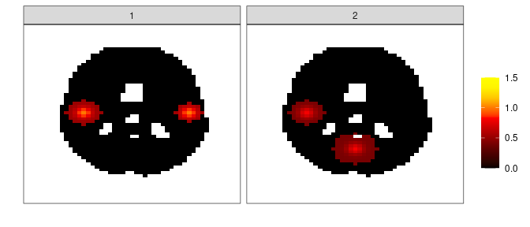

For model estimation, the data for each session must be formatted into a `session` object, defined as a list with elements `BOLD` (the response), `design` (the design matrix), and (optionally) `nuisance` (a design matrix for nuisance regressors). Multiple sessions are combined into a list (in this example, there is a single session). The function `simulate_slice_data()` returns the data already in this format:

```r
names(simulated_data$data$session_1)
```

```
#> [1] "BOLD"   "design"
```

```r
is.session(simulated_data$data$session_1)
```

```
#> [1] TRUE
```

With the data created and in the correct format, the analysis can begin!

## Classical GLM

We can fit a classical GLM to the data using the `classicalGLM()` function. Note that by default, the BOLD data and the design are scaled so that the estimated coefficients for each task represent the percent signal change associated with each task. For simulated data, we do not scale to avoid inducing changes to the true beta coefficient maps. The resulting images of the point estimates for the coefficients can be seen below.

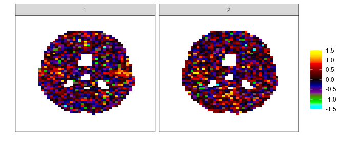

```r
single_session_classical <- classicalGLM(data = simulated_data$data, scale_BOLD = FALSE, scale_design = FALSE)
classical_estimates <- vec2image(single_session_classical$session_1, template_image = binary_template)
plot_slice(classical_estimates, zlim = c(-1.5,1.5))
```

While there is a small increase in the average coefficient value around the true areas of activation, these areas are difficult to distinguish using the classical GLM approach due to the level of the noise in the estimates.

## Bayesian GLM

Now we start preparing to fit the spatial Bayesian GLM. The data locations must be part of a triangular mesh. This is the format of cortical surface fMRI data, but a triangular mesh can also be constructed for a slice of volumetric fMRI data as in this simulation. Ideally the mesh will be “padded” with boundary layers of larger triangles to avoid undesirable boundary effects on the data locations. Here we use the `make_slice_mesh()` function to construct a mesh from a brain mask. The plotted mesh below shows a fine mesh corresponding to data locations (inside the mask), surrounded by boundary layers of increasingly larger triangles.

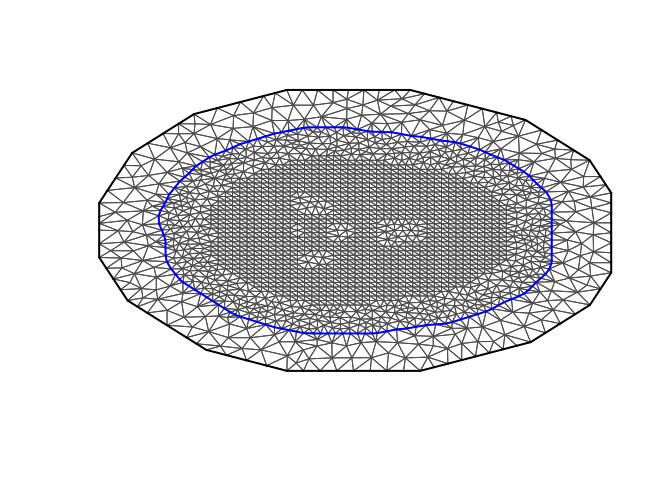

```r
mesh <- make_slice_mesh(binary_template)
plot(mesh, main = "")
```

*Note: INLA reads indices in a different order than the default R behavior. That is, the first index corresponds to columns and the second refers to rows. This is why the mesh appears to be a transposed image of a brain slice when compared to the activation amplitudes shown above.*

Next, the spatial Bayesian GLM can be estimated using the `BayesGLM()` function. As in the classical GLM, we do not scale the timeseries or the design matrix to avoid inducing changes in the true beta coefficients. **Note: Model is pre-computed. Set `eval=TRUE` to compute. For this dataset, the expected computation time is approximately 5 minutes with PARDISO enabled.**

```r
single_session_result <- BayesGLM(data = simulated_data$data, mesh = mesh, scale_BOLD = FALSE, scale_design = FALSE, verbose = FALSE, return_INLA_result=FALSE)
saveRDS(single_session_result, "single_session_BayesGLM_results.rds")
```

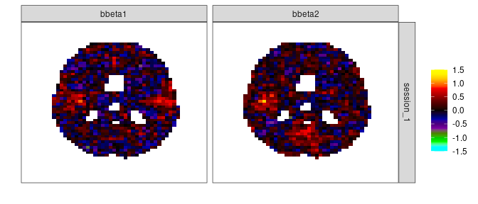

```r
plot_BayesGLM_slice(single_session_result, mask = binary_template, zlim = c(-1.5,1.5))
```

# Single-Subject, Multi-Session Analysis

In some cases, a single subject may undergo more than one session in a task fMRI study or be studied longitudinally. The `BayesGLM()` function can combine multiple sessions into a single model, lending more efficiency to estimation of model parameters controlling the properties of each latent field. Estimates of task activation are computed for each session, which may be of individual interest. In addition, contrasts across sessions (e.g. the between-session average) can be modeled, increasing estimation efficiency and power to identify areas of activation.

## Data Generation

Data were generated as in the single-session analysis, with a slight modification. Now the true activation fields for the different sessions were jittered in space, intensity, and smoothness.

This results in the true activation amplitudes:

Session 1:

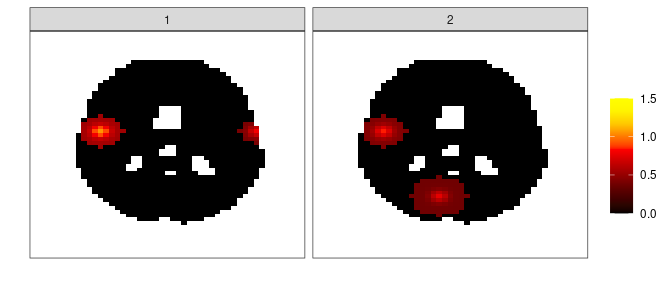

Session 2:

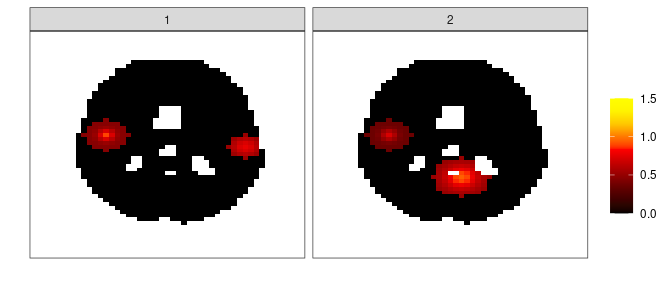

The function `simulate_slice_data()` formats the data into a list of “session” objects, which we can then pass to `BayesGLM` for analysis. **Note: Model is pre-computed. Set `eval=TRUE` to compute. Expected computation time is approximately 10 minutes with PARDISO enabled.**

```r
# Run the model in INLA
multi_session_result <- BayesGLM(data=multi_data$data, mesh=mesh, scale_BOLD = FALSE, scale_design = FALSE, verbose = FALSE, return_INLA_result=FALSE)
saveRDS(multi_session_result, "multi_session_BayesGLM_results.rds")
```

## Results

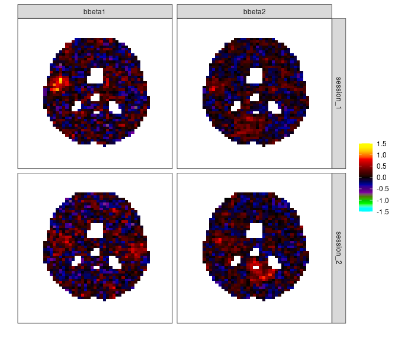

```r
plot_BayesGLM_slice(multi_session_result, mask = binary_template, zlim = c(-1.5,1.5))
```